# Multi Comparison Problem Set

Your Name Here

# 1 Introduction

This problem set corresponds to the section on multi factor ANOVA in the course https://jacobshermansd.github.io/parametric-trades.

For this problem set, we will use the following packages:

```r
library(tidyverse)
```

# 2 Active Protection System

## 2.1 Read the Data

Read the data and clean / format it as necessary.

```r
# Read my data.
aps <- read.csv('./aps.csv')
# View the data
head(aps)
```

```
##      A    B    C    D    E
## 1 26.4 25.8 28.8 25.7 27.3
## 2 27.3 25.6 28.6 26.2 28.5
## 3 28.8 25.6 29.8 26.0 27.5
## 4 28.2 25.5 29.1 26.1 27.8
## 5 29.6 26.4 27.4 25.7 27.3
## 6 29.5 26.8 28.9 26.3 27.9
```

```r
# Format Data into a usable format
aps <- aps %>%
  pivot_longer(cols = c(A, B, C, D, E), names_to = 'APS.Type', values_to = 'Losses') %>%
  mutate(APS.Type = as.factor(APS.Type))

# View the data
head(aps)
```

```
## # A tibble: 6 x 2
##   APS.Type Losses
##   <fct>     <dbl>
## 1 A          26.4
## 2 B          25.8
## 3 C          28.8
## 4 D          25.7
## 5 E          27.3
## 6 A          27.3
```

## 2.2 Tukey Test

Assume that you have already done your ANOVA and identified that the choice of APS has a statistically significant effect.

Conduct a Tukey HSD test to determine which levels are distinct at a 95% confidence level. Visualize this result. Interpret your results.

```r
# Conduct the Tukey HSD test.  Note 95% is the default confidence level
aps.tukey <- TukeyHSD(aov(Losses ~ APS.Type, data = aps))

# View the results:
aps.tukey
```

```
##   Tukey multiple comparisons of means
##     95% family-wise confidence level
##
## Fit: aov(formula = Losses ~ APS.Type, data = aps)
##
## $APS.Type
##           diff        lwr        upr     p adj
## B-A -2.3500000 -3.6123613 -1.0876387 0.0001015
## C-A  0.4666667 -0.7956946  1.7290279 0.8121041
## D-A -2.3000000 -3.5623613 -1.0376387 0.0001362
## E-A -0.5833333 -1.8456946  0.6790279 0.6593835
## C-B  2.8166667  1.5543054  4.0790279 0.0000068
## D-B  0.0500000 -1.2123613  1.3123613 0.9999555
## E-B  1.7666667  0.5043054  3.0290279 0.0031388
## D-C -2.7666667 -4.0290279 -1.5043054 0.0000090
## E-C -1.0500000 -2.3123613  0.2123613 0.1368923
## E-D  1.7166667  0.4543054  2.9790279 0.0041890
```

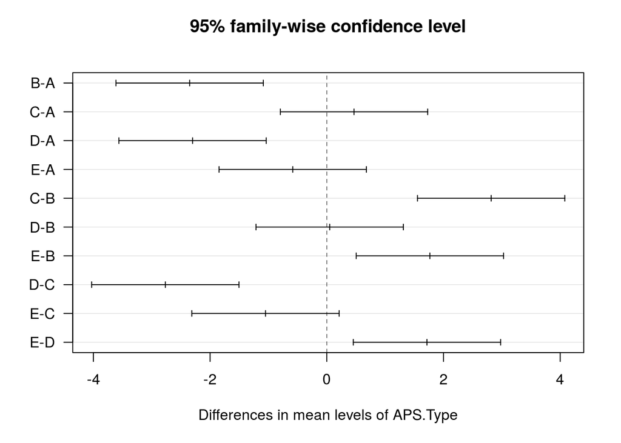

```r
plot(aps.tukey, las = 1)
```

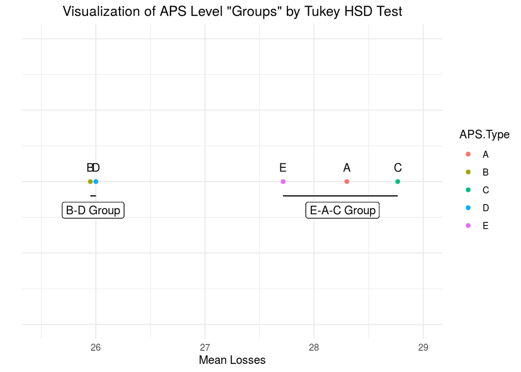

```r
# Using Alpha = .05: We cannot say the following pairs are distinct
# A vs. C
# A vs. E
# B vs. D
# E vs. C
# Effectively, what we are saying is:
# A, C, and E cannot be distinguished from each other
# B and D cannot be distinguished from each other
# So we have 2 x groups of APS

# Sometimes it is useful to see this graphically by the means
aps.summary <- aps %>%
  group_by(APS.Type) %>% summarise(mean = mean(Losses)) %>% arrange(mean)

ggplot(aps.summary) +
  # Plot the mean values for each level of APS
  geom_point(aes(x = mean, y = 1, color = APS.Type)) +
  # Label the mean values (also identified by color)
  geom_text(aes(x = mean, y = 1.1, label = APS.Type)) +
  # Produce a line segement that identifies teh groups indicated above
  # Note this is simply hard coded from the analysis above
  geom_segment(aes(x = mean[APS.Type == 'B'], xend = mean[APS.Type == 'D'],
                   y = .9, yend = .9)) +
  geom_segment(aes(x = mean[APS.Type == 'E'], xend = mean[APS.Type == 'C'],
                   y = .9, yend = .9)) +
  # Label the two groups
  geom_label(aes(x = mean(mean[APS.Type %in% c('B', 'D')]), y = .8, label = 'B-D Group')) +
  geom_label(aes(x = mean(mean[APS.Type %in% c('E', 'A', 'C')]), y = .8, label = 'E-A-C Group')) +
  # Vary the theme so the plot looks nice
  theme_minimal() + theme(axis.text.y = element_blank(), plot.title = element_text(hjust = .5)) +
  # Label the axes and title
  xlab('Mean Losses') + ylab('') +
  ggtitle('Visualization of APS Level "Groups" by Tukey HSD Test') +
  # Vary the scale so the plot looks nice
  ylim(c(0, 2)) + xlim(c(25.5, 29))
```

```r
# Finally, you can tell a decision maker that it makes the most sense
# (all other things being equal) to focus efforts on APS system B or D as it preserves about
# 2 more platforms than E, A, and C.  Further, one cannot really distinguish between
# APS system E and C even though their mean results do look different (for example).
```

# 3 Multi Factor Data

In the multi-factor comparison problem set recall that we had a response with four factors (A, B, C, and D) that could each take on a low or high level (represented by ‘-1’ and ‘1’ respectively). When we did the ANOVA that only showed main and 2-way interactions, we showed that the interaction between Factor A and Factor B was significant (i.e., at least one of the levels of ‘A:B’ had a mean that was statistically different from the others). Use multi_factor.csv and a Tukey HSD test to show which of the levels of ‘A:B’ are distinct.

Conduct a Tukey HSD test and show your results graphically to show what levels of A:B can be considered distinct from the others (use a 99% confidence level).

```r
# Read the data
mf <- read.csv('./multi_factor.csv')

mf <- mf %>%
  # I did this after the fact.  The labels in the TukeyHSD became cryptic
  # This simply renames any row in the A column valued as 1 as 'A.High'
  # else it provides it the value of A.Low
  # the ifelse(boolean, True Result, False Result) is a highly useful one
  mutate(A = ifelse(A == 1, 'A.High', 'A.Low')) %>%
  mutate(B = ifelse(B == 1, 'B.High', 'B.Low')) %>%
  # Convert the factor levels to a factor data type
  mutate(A = as.factor(A), B = as.factor(B), C = as.factor(C), D = as.factor(D))

head(mf)
```

```
##   Response      A      B  C  D
## 1     1.92  A.Low  B.Low -1 -1
## 2    11.28 A.High  B.Low -1 -1
## 3     1.09  A.Low B.High -1 -1
## 4     5.75 A.High B.High -1 -1
## 5     2.13  A.Low  B.Low  1 -1
## 6     9.53 A.High  B.Low  1 -1
```

```r
# Conduct the ANOVA
mf.aov <- aov(Response ~ . + .:., data = mf)

# Do a Tukey test on the A:B factor from the above ANOVA
# The which tells you which factor to consider
# the conf.level tells you which level to consider
mf.tukey <- TukeyHSD(mf.aov, which = 'A:B', conf.level = .99)

# We want to view the results
mf.tukey
```

```
##   Tukey multiple comparisons of means
##     99% family-wise confidence level
##
## Fit: aov(formula = Response ~ . + .:., data = mf)
##
## $`A:B`
##                               diff        lwr        upr     p adj
## A.Low:B.High-A.High:B.High -4.1825  -6.949418 -1.4155822 0.0015563
## A.High:B.Low-A.High:B.High  5.1425   2.375582  7.9094178 0.0005862
## A.Low:B.Low-A.High:B.High  -3.3175  -6.084418 -0.5505822 0.0045019
## A.High:B.Low-A.Low:B.High   9.3250   6.558082 12.0919178 0.0000314
## A.Low:B.Low-A.Low:B.High    0.8650  -1.901918  3.6319178 0.4008684
## A.Low:B.Low-A.High:B.Low   -8.4600 -11.226918 -5.6930822 0.0000498
```

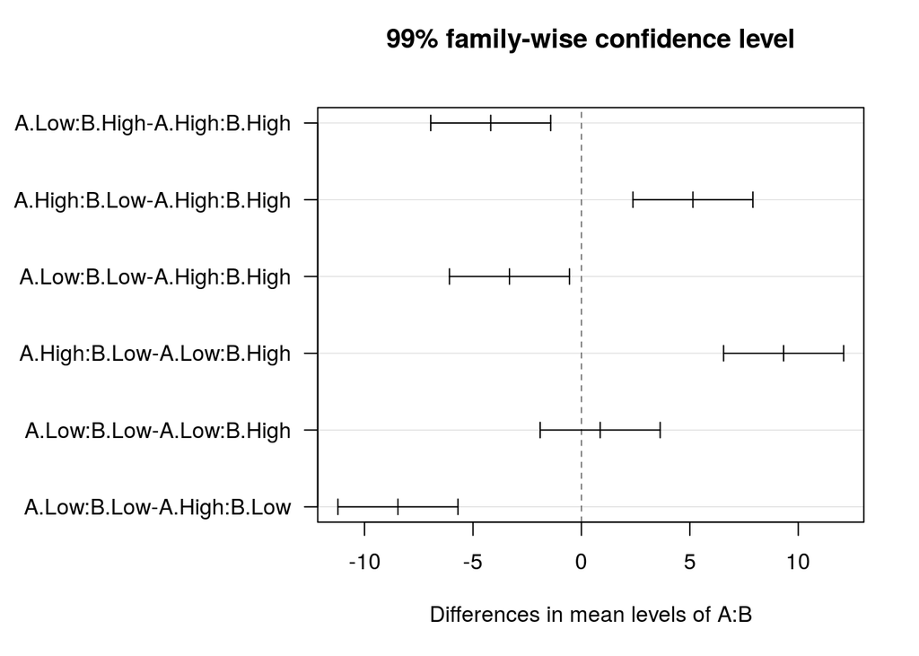

```r
# Recall what this says.  For each level, it gives us a comparison
# between two levels of A:B.  Recall the levels of A:B will be something
# like "A.level : B.level.  There are, accordingly 4 x levels of A:B
# and 4 choose 2 = 6 combinations of the levels
# This shows the confidence interval on the value of (Level 1) - (Level 2).  If
# 0 is included in this confidence interval, it is unlikely the two levels have different means.
# From this we can say it appears that we cannot really say there is a distinction between
# (A Low : B Low) and (A Low : B High)
# All of the rest appear to be distinct

# View the results graphically
# Set base R parameters; mar specifies the margin, make the left margin larger
# to allow for the long level names (useful to read ?par)
par(mar=c(5,12,4,2) + .1)
# plot the TukeyHSD results, las = 1 rotates the y axis text
plot(mf.tukey, las = 1)
```

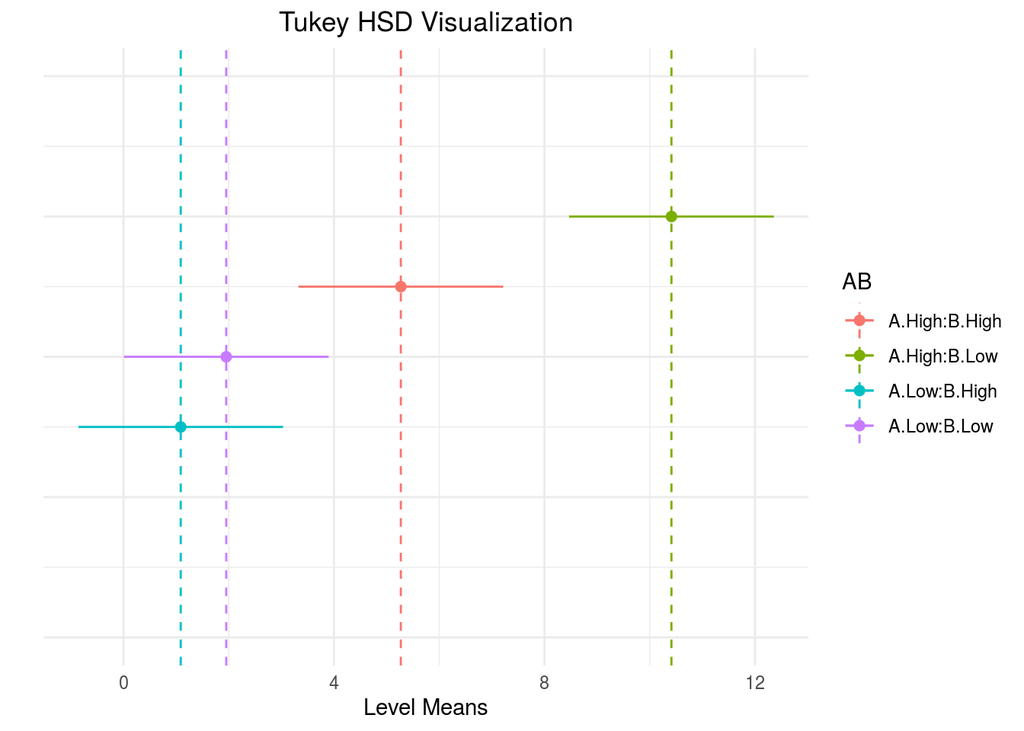

```r
# We see the results above graphically


# We can also show the same results in a different way using the w value:

# calculate W (see tutorial section)
alpha <- .01 # as identified in the problem
a <- 4 # as there are 4 x levels for A:B
n <- 4 # as each A:B level has 4 x observations
mse <- .5 # as taken from the mf.aov table
q <- qtukey(alpha, a, a*(n-1), lower.tail = F) # q value
w <- q*sqrt(mse/n)

# Summarize the data
mf.summary <- mf %>%
  # First, I found it useful to create a new name for the levels
  # I called 'AB' that is the combinatino of the name of A and B
  # paste is a means to concatenate 2 or more strings
  mutate(AB = paste(A, ':', B, sep = '')) %>%
  # Group the data by the AB value
  group_by(AB) %>%
  # Get the means
  summarise(sample.mean = mean(Response)) %>%
  # Order the data by the sample means
  arrange(sample.mean)

# Plot the data
ggplot(data = mf.summary) +
  # This plots the mean of each point, colored by AB level
  geom_point(aes(x = sample.mean, y = 1:nrow(mf.summary), color = AB), size = 2) +
  # This creates a line segment from the level's mean to mean + w
  geom_segment(aes(x = sample.mean, xend = sample.mean + w, y = 1:nrow(mf.summary),
                   yend = 1:nrow(mf.summary), color = AB)) +
  # This creates a line segment from the level's mean to mean - w
  geom_segment(aes(x = sample.mean, xend = sample.mean - w,
                   y = 1:nrow(mf.summary), yend = 1:nrow(mf.summary), color = AB)) +
  # This creates a vertical line to more easily see the means
  geom_vline(aes(xintercept = sample.mean, color = AB), lty = 2) +
  # This adjusts the theme (note, the y axis is meaningless)
  theme_minimal() + theme(axis.text.y = element_blank(), plot.title = element_text(hjust = .5)) +
  # This scales the y axis so the plot looks as I like it
  ylim(c(0 - .5*nrow(mf.summary), nrow(mf.summary) + .5*nrow(mf.summary))) +
  ylab('') + xlab('Level Means') +
  ggtitle('Tukey HSD Visualization')
```

```r
# From this, we see the same thing as the previous analysis
# It shows us the we cannot distinguish between (A Low : B Low) and (A Low : B High)

# Note that the question is if two means fall within W, so the fact that the line segments
# overlap for Purple (A Low : B Low) and Red (A High : B High) does not indicate that
# we cannot distinguish the means.
```

[^1]: Note, your simulation is an aggregate one, so you can receive partial losses, e.g. 12.3